# A3: Incarceration

### Introduction

For as long as the United States has been around, racism has existed, and in the past century, one one of the most prominent ways that racism has manifested has been through the incarceration system. I decided to analyze prison and jail populations per county/state. Some specific variables that I decided to analyze were incarcerations based on race, state, etc. The reason I want to look at these variables is because they in my opinion provide the most insight in terms of both state values, as well as overall rates of incarceration based on race.

### Summary Information

While going through the data, some of the things that I found included the most recently recorded highest prison population which was in CA, 2016 (California). While the lowest most recent recorded prison population was in CO, 2016 (Colorado). The highest ratio of black prisoners to total prisoners was in LA (Louisiana). The highest amount of POCs in prison was 25074. And the year with the most prisoners incarcerated was in 2007, CA.

### The Dataset

Who collected the data?

- The data was collected by the Vera Institute.

How was the data collected or generated?

- Collected from various sources (BJS, which includes data from COJ, ASJ, etc.) and aggregated into a CSV.

Why was the data collected?

- The data was collected in order to better understand the various incarcerations systems in place in the United States so that they could more effectively understand the effects of these systems and how to deal with them.

How many observations (rows) are in your data?

- 153811

How many features (columns) are in the data?

- 36 (Prison)

What, if any, ethical questions or questions of power do you need to consider when working with this data?

- One question that I have is how some categorical values like race are determined when it comes to mixed ethnicity, or similar?

What are possible limitations or problems with this data? (at least 200 words)

- One of the primary issues with all the data sets that are included in the Vera Institute study is that there are a lot of Not Applicable or missing values in the data set. While this is workable, as it is possible to simply just remove the missing/not applicable data, it does detract from the completeness of any finding that we make from the data. This can be noted in the case where we want to calculate an average or median from the values, but there is a large hole in the data set from a specific set of years, which when removed could seriously skew the results in a particular direction. If there are important years to consider in history, but those results are removed from the data set, this will serve as a huge hindrance. Not only that, but a lot of the information on the data set and the way that they are formatted are more on the dated side, especially when you consider that only male and female is accounted for, which is a problem since in today’s society, the concept of binary gender has largely been done away with and we should be considering everyone’s unique identity.

### Trends Over Time Chart

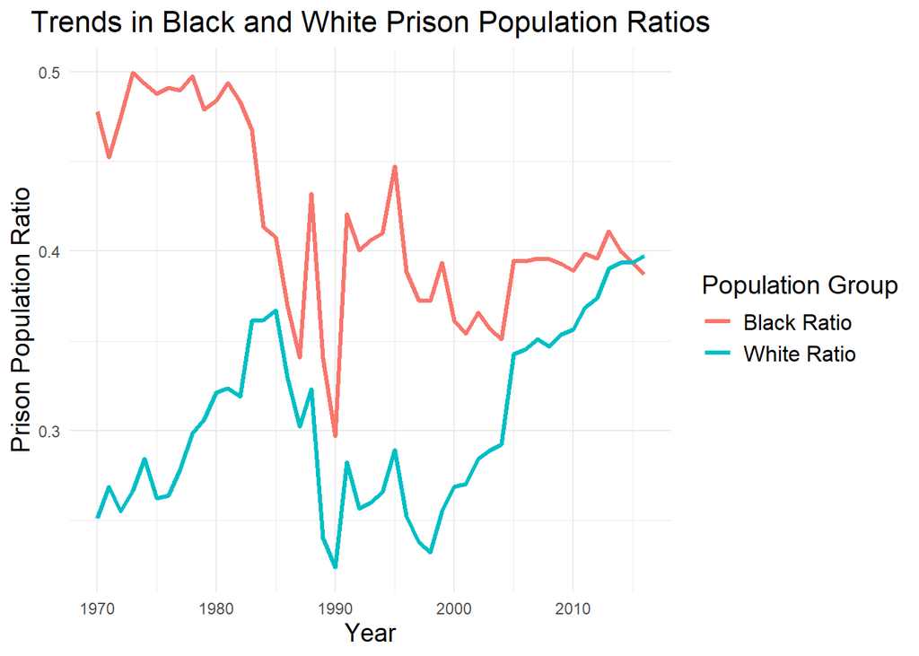

You can see in this graph how the proportion of black incarcerations in prison in comparison to the overall prisoner amount has consistently over the years been higher than the proportion of white incarcerations. It is important to note that towards the end of the graph roughly 2015, there seems to be a higher proportion of white inmates, however this could also be due to the lack of data around that time.

### Variable Comparison Chart

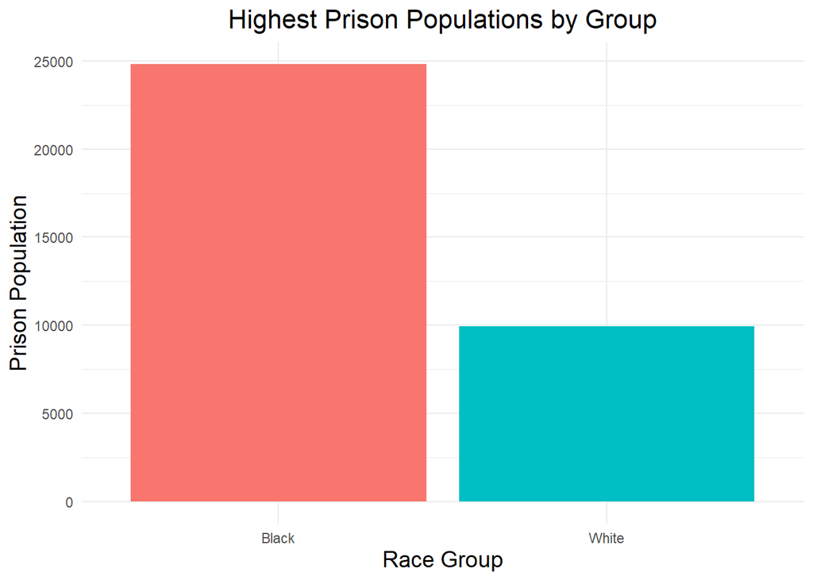

To get more perspective from the previous graph, I am using this bar graph to show just how disproportionate the actual incarceration rates are. The highest amount of white people incarcerated in prison are shown on the right versus the highest amount of black people incarcerated on the left. This is throughout all history, the highest amount of each race being locked up. The injustice is quite clear.

### Map

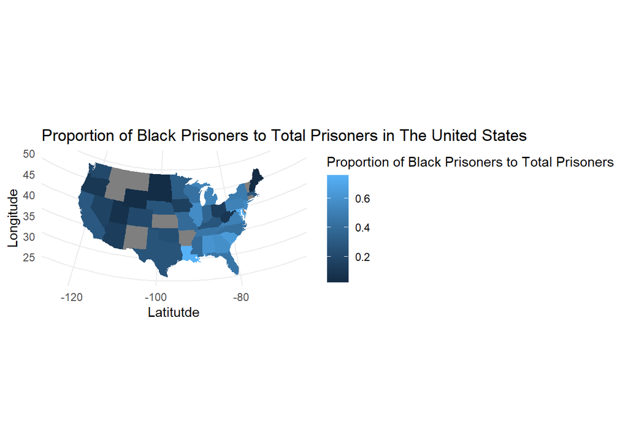

This map shows the proportions of black prisoners to total prisoners in each states. You can see how in some states there are no statistics taken due to lack of recording. Otherwise, the main observation is that the east has a higher proportion compared to western states, this is even with high population states like Texas and California.